# CropSyst calibration - spring canola

## Set up script

```r
library(ggplot2)
library(plyr)
setwd("C:\\Drive\\Files\\Projects\\FlexCropping\\Methods\\R\\CalibrationSpringCanola")
ggplotRegression <- function(path.obs, path.sim) {
  require(ggplot2)
  require(plyr)

  # Read data with observed yield
  df.obs <- read.table(path.obs, sep="\t", header=TRUE)

  # Read data with simulated yield, only read required columns
  columnClasses = c("Date", rep("NULL", 10), "numeric", rep("NULL", 70), rep("character", 3), "NULL")
  df.sim <- read.table(path.sim, colClasses = columnClasses, sep="\t", header=TRUE)

  # Convert units (from/to?) and extract planting year from date
  df.sim$yield <- df.sim$yield * 10000
  df.sim$Year <- as.numeric(substring(df.sim$planting_date,0,4))

  # Merge sim and obs dataframes by location and  year
  df <- merge(df.obs, df.sim, by=c("location", "Year"))

  # Rename yield columns for clarity
  df <- rename(df, c("Yield"="yield.obs", "yield"="yield.sim"))

  # Graph sim vs obs
  fit <- lm(yield.sim ~ yield.obs, data = df)
  print(summary(fit))
  ggplot(df, aes(x=df$yield.obs, y=df$yield.sim)) +
    geom_point(shape=1) +
    geom_abline(slope=1) +
    #geom_smooth(method='lm', se=TRUE) +
    stat_smooth(method="lm", formula = y ~ x, size=1) +
    coord_cartesian(xlim=c(0,5000), ylim=c(0,5000)) +
    labs(title = paste("Adj R2 = ",signif(summary(fit)$adj.r.squared, 5),
                       "Intercept =",signif(fit$coef[[1]],5 ),
                       " Slope =",signif(fit$coef[[2]], 5),
                       " P =",signif(summary(fit)$coef[2,4], 5)))
}
```

## Comparing obs to sim runs on 17-04-21

```
Call:
lm(formula = yield.sim ~ yield.obs, data = df)

Residuals:
   Min     1Q Median     3Q    Max
-938.7 -365.5 -147.4  574.1 1159.9

Coefficients:
             Estimate Std. Error t value Pr(>|t|)
(Intercept) 1576.4512   300.7189   5.242 1.07e-05 ***
yield.obs      0.3342     0.1291   2.589   0.0145 *
---
Signif. codes:  0 *** 0.001 ** 0.01 * 0.05 . 0.1   1

Residual standard error: 607.5 on 31 degrees of freedom
Multiple R-squared:  0.1777,    Adjusted R-squared:  0.1512
F-statistic: 6.701 on 1 and 31 DF,  p-value: 0.01454
```

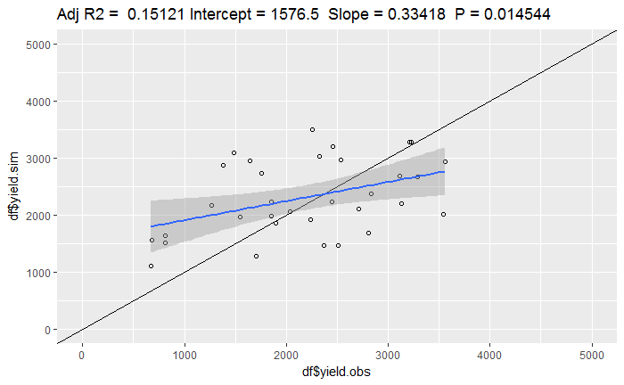

```r
ggplotRegression("Input\\observed_spring_canola_peas_wheat_planting_dates.txt", "Input\\17-04-21_season_all.dat")
```

## Obs vs 17-05-04

https://github.com/bryanrcarlson/LtarModelingFlexCropping_CropSyst/commit/8b214bae593ace8f291cd766bc34a4fc81ef2091#diff-8fb462d4d9caaeef85ac8a8f5a530157

```
Call:
lm(formula = yield.sim ~ yield.obs, data = df)

Residuals:
     Min       1Q   Median       3Q      Max
-1194.19  -622.75   -60.18   717.36  1187.26

Coefficients:
             Estimate Std. Error t value Pr(>|t|)
(Intercept) 1645.6757   367.4656   4.478 9.52e-05 ***
yield.obs      0.3072     0.1578   1.947   0.0606 .
---
Signif. codes:  0 *** 0.001 ** 0.01 * 0.05 . 0.1   1

Residual standard error: 742.3 on 31 degrees of freedom
Multiple R-squared:  0.109, Adjusted R-squared:  0.08023
F-statistic: 3.791 on 1 and 31 DF,  p-value: 0.06063
```

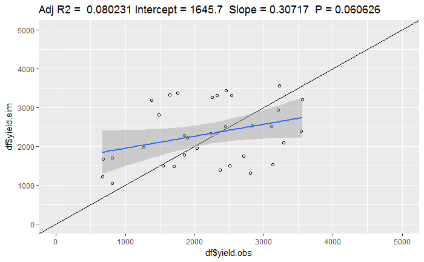

```r
ggplotRegression("Input\\observed_spring_canola_peas_wheat_planting_dates.txt", "Input\\17-05-04_season_all.dat")
```

## SC1 Adj LAI params

https://github.com/bryanrcarlson/LtarModelingFlexCropping_CropSyst/commit/b2d3aab9dabf1c671f75b06ba12dab220c381eb9#diff-8fb462d4d9caaeef85ac8a8f5a530157

```
Call:
lm(formula = yield.sim ~ yield.obs, data = df)

Residuals:
    Min      1Q  Median      3Q     Max
-1861.1  -666.7   190.5   473.2  1450.2

Coefficients:
             Estimate Std. Error t value Pr(>|t|)
(Intercept) 2199.6770   395.4381   5.563 4.28e-06 ***
yield.obs      0.7031     0.1698   4.142 0.000246 ***
---
Signif. codes:  0 *** 0.001 ** 0.01 * 0.05 . 0.1   1

Residual standard error: 798.9 on 31 degrees of freedom
Multiple R-squared:  0.3563,    Adjusted R-squared:  0.3355
F-statistic: 17.16 on 1 and 31 DF,  p-value: 0.0002458
```

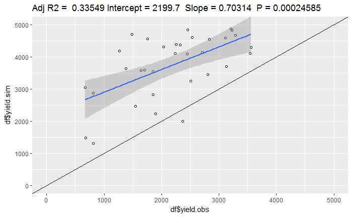

```r
ggplotRegression("Input\\observed_spring_canola_peas_wheat_planting_dates.txt", "Input\\17-05-05_1_season_all.dat")
```

## SC2 Adj HI

https://github.com/bryanrcarlson/LtarModelingFlexCropping_CropSyst/commit/58e2f90e260282fa531b800b20f1e008939a9f16#diff-8fb462d4d9caaeef85ac8a8f5a530157

```
Call:
lm(formula = yield.sim ~ yield.obs, data = df)

Residuals:
    Min      1Q  Median      3Q     Max
-1388.0  -583.9   116.8   453.9  1154.0

Coefficients:
             Estimate Std. Error t value Pr(>|t|)
(Intercept) 1923.7513   309.4450   6.217 6.63e-07 ***
yield.obs      0.5423     0.1328   4.082 0.000291 ***
---
Signif. codes:  0 *** 0.001 ** 0.01 * 0.05 . 0.1   1

Residual standard error: 625.1 on 31 degrees of freedom
Multiple R-squared:  0.3496,    Adjusted R-squared:  0.3286
F-statistic: 16.66 on 1 and 31 DF,  p-value: 0.0002908
```

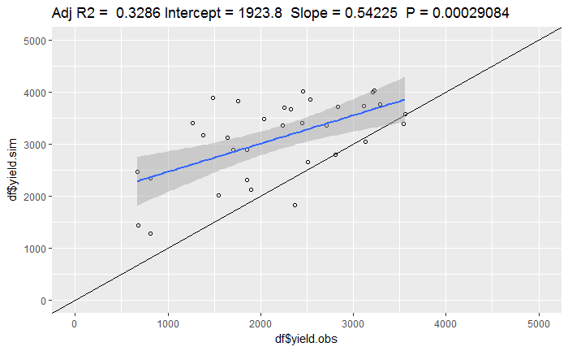

```r
ggplotRegression("Input\\observed_spring_canola_peas_wheat_planting_dates.txt", "Input\\17-05-05_2_season_all.dat")
```

## SC3 Adj TUE

https://github.com/bryanrcarlson/LtarModelingFlexCropping_CropSyst/commit/e729c39098aacbefd5bba7098fe237761e99a036#diff-8fb462d4d9caaeef85ac8a8f5a530157

```
Call:
lm(formula = yield.sim ~ yield.obs, data = df)

Residuals:
     Min       1Q   Median       3Q      Max
-1052.02  -480.26   -60.47   494.69  1089.29

Coefficients:
             Estimate Std. Error t value Pr(>|t|)
(Intercept) 1564.9706   288.1765   5.431 6.25e-06 ***
yield.obs      0.4626     0.1237   3.739  0.00075 ***
---
Signif. codes:  0 *** 0.001 ** 0.01 * 0.05 . 0.1   1

Residual standard error: 582.2 on 31 degrees of freedom
Multiple R-squared:  0.3108,    Adjusted R-squared:  0.2886
F-statistic: 13.98 on 1 and 31 DF,  p-value: 0.0007495
```

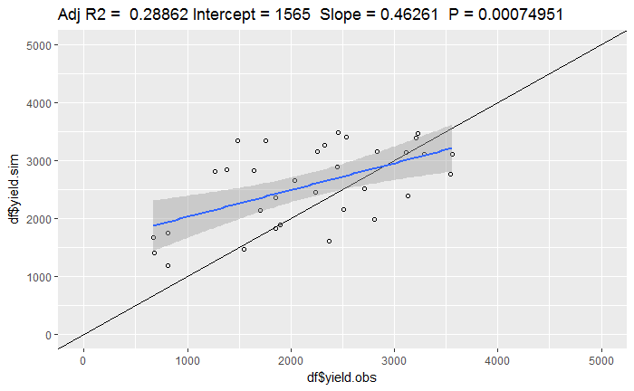

```r
ggplotRegression("Input\\observed_spring_canola_peas_wheat_planting_dates.txt", "Input\\17-05-05_3_season_all.dat")
```

## SC4 Adj SLA and LAI

https://github.com/bryanrcarlson/LtarModelingFlexCropping_CropSyst/commit/eb40dd9abb93855ef49fa028c964749cf853e468#diff-8fb462d4d9caaeef85ac8a8f5a530157

```
Call:
lm(formula = yield.sim ~ yield.obs, data = df)

Residuals:
   Min     1Q Median     3Q    Max
-981.4 -516.3 -214.1  656.3 1173.8

Coefficients:
             Estimate Std. Error t value Pr(>|t|)
(Intercept) 1452.4452   315.4908   4.604 6.66e-05 ***
yield.obs      0.4114     0.1354   3.038   0.0048 **
---
Signif. codes:  0 *** 0.001 ** 0.01 * 0.05 . 0.1   1

Residual standard error: 637.4 on 31 degrees of freedom
Multiple R-squared:  0.2294,    Adjusted R-squared:  0.2045
F-statistic: 9.229 on 1 and 31 DF,  p-value: 0.004804
```

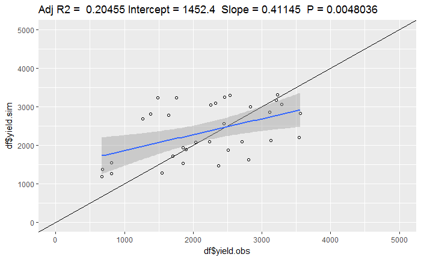

```r
ggplotRegression("Input\\observed_spring_canola_peas_wheat_planting_dates.txt", "Input\\17-05-05_4_season_all.dat")
```

## SC5: Increased TUE and HI stressors

https://github.com/bryanrcarlson/LtarModelingFlexCropping_CropSyst/commit/6333ea5683062ff34af80f17d2d33d958c24debc#diff-8fb462d4d9caaeef85ac8a8f5a530157

```
Call:
lm(formula = yield.sim ~ yield.obs, data = df)

Residuals:
    Min      1Q  Median      3Q     Max
-2153.2  -874.0   162.6   661.4  1875.2

Coefficients:
             Estimate Std. Error t value Pr(>|t|)
(Intercept) 2002.5989   513.9738   3.896 0.000487 ***
yield.obs      0.9102     0.2206   4.125 0.000258 ***
---
Signif. codes:  0 *** 0.001 ** 0.01 * 0.05 . 0.1   1

Residual standard error: 1038 on 31 degrees of freedom
Multiple R-squared:  0.3544,    Adjusted R-squared:  0.3336
F-statistic: 17.02 on 1 and 31 DF,  p-value: 0.0002575
```

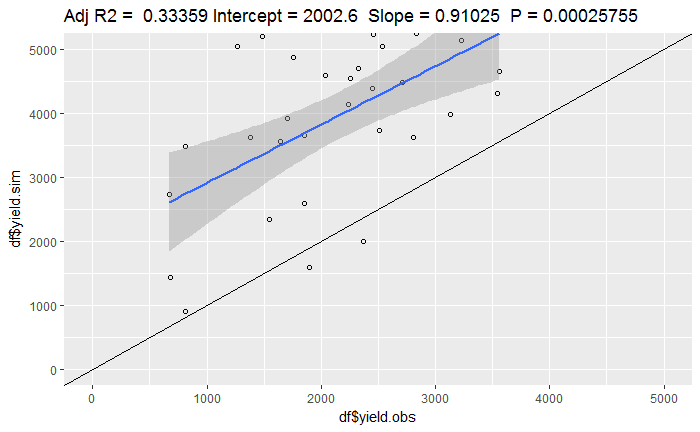

```r
ggplotRegression("Input\\observed_spring_canola_peas_wheat_planting_dates.txt", "Input\\17-05-05_5_season_all.dat")
```

## SC6: Reduced TUE and HI a bit

https://github.com/bryanrcarlson/LtarModelingFlexCropping_CropSyst/commit/8e4f3555a4157f2e2890dd69ce23f4573232b42d#diff-8fb462d4d9caaeef85ac8a8f5a530157

```r
ggplotRegression("Input\\observed_spring_canola_peas_wheat_planting_dates.txt", "Input\\17-05-05_6_season_all.dat")
```

```
Call:
lm(formula = yield.sim ~ yield.obs, data = df)

Residuals:
    Min      1Q  Median      3Q     Max
-1411.1  -663.6   -25.7   624.0  1622.5

Coefficients:
             Estimate Std. Error t value Pr(>|t|)
(Intercept) 1683.1951   429.2653   3.921 0.000455 ***
yield.obs      0.6763     0.1843   3.670 0.000906 ***
---
Signif. codes:  0 *** 0.001 ** 0.01 * 0.05 . 0.1   1

Residual standard error: 867.2 on 31 degrees of freedom
Multiple R-squared:  0.3029,    Adjusted R-squared:  0.2804
F-statistic: 13.47 on 1 and 31 DF,  p-value: 0.0009055
```

## SC7: Increased stressors

https://github.com/bryanrcarlson/LtarModelingFlexCropping_CropSyst/commit/0ff1c05930f33bb1c8ab569eaf38986d6d44699c#diff-5bf50174d60077ff41a0967d09ac9250

```r
ggplotRegression("Input\\observed_spring_canola_peas_wheat_planting_dates.txt", "Input\\17-05-08_7_season_all.dat")
```

```
Call:
lm(formula = yield.sim ~ yield.obs, data = df)

Residuals:
    Min      1Q  Median      3Q     Max
-1411.1  -663.6   -25.7   624.0  1622.5

Coefficients:
             Estimate Std. Error t value Pr(>|t|)
(Intercept) 1683.1951   429.2653   3.921 0.000455 ***
yield.obs      0.6763     0.1843   3.670 0.000906 ***
---
Signif. codes:  0 *** 0.001 ** 0.01 * 0.05 . 0.1   1

Residual standard error: 867.2 on 31 degrees of freedom
Multiple R-squared:  0.3029,    Adjusted R-squared:  0.2804
F-statistic: 13.47 on 1 and 31 DF,  p-value: 0.0009055
```

- That did nothing!! It’s all lies!

## SC8: Second attempt at stressors: https://github.com/bryanrcarlson/LtarModelingFlexCropping_CropSyst/commit/9a7c409eec586544a684040833f825d0a00a809b#diff-5bf50174d60077ff41a0967d09ac9250

```r
ggplotRegression("Input\\observed_spring_canola_peas_wheat_planting_dates.txt", "Input\\17-05-08_8_season_all.dat")
```

```
Call:
lm(formula = yield.sim ~ yield.obs, data = df)

Residuals:
    Min      1Q  Median      3Q     Max
-1411.1  -663.6   -25.7   624.0  1622.5

Coefficients:
             Estimate Std. Error t value Pr(>|t|)
(Intercept) 1683.1951   429.2653   3.921 0.000455 ***
yield.obs      0.6763     0.1843   3.670 0.000906 ***
---
Signif. codes:  0 *** 0.001 ** 0.01 * 0.05 . 0.1   1

Residual standard error: 867.2 on 31 degrees of freedom
Multiple R-squared:  0.3029,    Adjusted R-squared:  0.2804
F-statistic: 13.47 on 1 and 31 DF,  p-value: 0.0009055
```

- Tried adjusting params twice, no effect!

## SC9: Increased dd for emergence 90 -> 100

https://github.com/bryanrcarlson/LtarModelingFlexCropping_CropSyst/commit/1b3737b5429bc3b8909d1ab7fe7b0e574ff08a03#diff-5bf50174d60077ff41a0967d09ac9250

```
Call:
lm(formula = yield.sim ~ yield.obs, data = df)

Residuals:
     Min       1Q   Median       3Q      Max
-1370.31  -687.48   -75.31   707.64  1660.68

Coefficients:
             Estimate Std. Error t value Pr(>|t|)
(Intercept) 1703.1389   440.8128   3.864 0.000533 ***
yield.obs      0.5956     0.1892   3.147 0.003628 **
---
Signif. codes:  0 *** 0.001 ** 0.01 * 0.05 . 0.1   1

Residual standard error: 890.5 on 31 degrees of freedom
Multiple R-squared:  0.2422,    Adjusted R-squared:  0.2177
F-statistic: 9.906 on 1 and 31 DF,  p-value: 0.003628
```

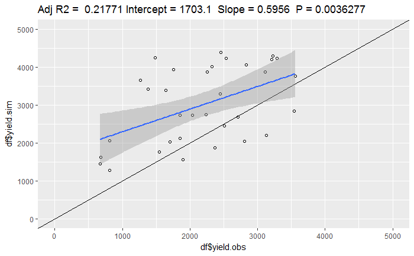

```r
ggplotRegression("Input\\observed_spring_canola_peas_wheat_planting_dates.txt", "Input\\17-05-08_9_season_all.dat")
```

## SC10: Rolled back emergence DD, and some stressors, decreased translocation factor and HI

https://github.com/bryanrcarlson/LtarModelingFlexCropping_CropSyst/commit/e1775f1b00d69067b8897e5476534fc2e04a5af7#diff-8fb462d4d9caaeef85ac8a8f5a530157

```r
ggplotRegression("Input\\observed_spring_canola_peas_wheat_planting_dates.txt", "Input\\17-05-08_10_season_all.dat")
```

```
Call:
lm(formula = yield.sim ~ yield.obs, data = df)

Residuals:
     Min       1Q   Median       3Q      Max
-1762.55  -646.71    75.05   650.37  1691.15

Coefficients:
             Estimate Std. Error t value Pr(>|t|)
(Intercept) 1676.6646   457.9619   3.661 0.000928 ***
yield.obs      0.7452     0.1966   3.790 0.000652 ***
---
Signif. codes:  0 *** 0.001 ** 0.01 * 0.05 . 0.1   1

Residual standard error: 925.2 on 31 degrees of freedom
Multiple R-squared:  0.3167,    Adjusted R-squared:  0.2946
F-statistic: 14.37 on 1 and 31 DF,  p-value: 0.0006521
```

## SC11: flowering_sensitivity 0.8 -> 1

https://github.com/bryanrcarlson/LtarModelingFlexCropping_CropSyst/commit/46acd8bb718353ce3fa0aa626627845847086919#diff-5bf50174d60077ff41a0967d09ac9250

```r
ggplotRegression("Input\\observed_spring_canola_peas_wheat_planting_dates.txt", "Input\\17-05-08_11_season_all.dat")
```

```
Call:
lm(formula = yield.sim ~ yield.obs, data = df)

Residuals:
     Min       1Q   Median       3Q      Max
-1762.55  -646.71    75.05   650.37  1691.15

Coefficients:
             Estimate Std. Error t value Pr(>|t|)
(Intercept) 1676.6646   457.9619   3.661 0.000928 ***
yield.obs      0.7452     0.1966   3.790 0.000652 ***
---
Signif. codes:  0 *** 0.001 ** 0.01 * 0.05 . 0.1   1

Residual standard error: 925.2 on 31 degrees of freedom
Multiple R-squared:  0.3167,    Adjusted R-squared:  0.2946
F-statistic: 14.37 on 1 and 31 DF,  p-value: 0.0006521
```

- No change!

## SC12: Incrased time of filling from 1 day to 14

https://github.com/bryanrcarlson/LtarModelingFlexCropping_CropSyst/commit/f1c2d010ef6cc8c6742cd04311a2c4fca9badc70#diff-8fb462d4d9caaeef85ac8a8f5a530157

```r
ggplotRegression("Input\\observed_spring_canola_peas_wheat_planting_dates.txt", "Input\\17-05-08_12_season_all.dat")
```

```
Call:
lm(formula = yield.sim ~ yield.obs, data = df)

Residuals:
     Min       1Q   Median       3Q      Max
-1762.55  -646.71    75.05   650.37  1691.15

Coefficients:
             Estimate Std. Error t value Pr(>|t|)
(Intercept) 1676.6646   457.9619   3.661 0.000928 ***
yield.obs      0.7452     0.1966   3.790 0.000652 ***
---
Signif. codes:  0 *** 0.001 ** 0.01 * 0.05 . 0.1   1

Residual standard error: 925.2 on 31 degrees of freedom
Multiple R-squared:  0.3167,    Adjusted R-squared:  0.2946
F-statistic: 14.37 on 1 and 31 DF,  p-value: 0.0006521
```

## SC13: root_sensitivity_water_stress 0.3 -> 1

https://github.com/bryanrcarlson/LtarModelingFlexCropping_CropSyst/commit/180cb54e9d272c89e49cd244071ec9c146d4dc7e#diff-8fb462d4d9caaeef85ac8a8f5a530157

```r
ggplotRegression("Input\\observed_spring_canola_peas_wheat_planting_dates.txt", "Input\\17-05-09_13_season_all.dat")
```

```
Call:
lm(formula = yield.sim ~ yield.obs, data = df)

Residuals:
     Min       1Q   Median       3Q      Max
-1762.55  -646.71    75.05   650.37  1691.15

Coefficients:
             Estimate Std. Error t value Pr(>|t|)
(Intercept) 1676.6646   457.9619   3.661 0.000928 ***
yield.obs      0.7452     0.1966   3.790 0.000652 ***
---
Signif. codes:  0 *** 0.001 ** 0.01 * 0.05 . 0.1   1

Residual standard error: 925.2 on 31 degrees of freedom
Multiple R-squared:  0.3167,    Adjusted R-squared:  0.2946
F-statistic: 14.37 on 1 and 31 DF,  p-value: 0.0006521
```

- CROPSYST!

## SC14: heat_stress_no_stress_threshold_temperature: 32 -> 30, heat_stress_max_stress_threshold_temperature: 38 -> 36

https://github.com/bryanrcarlson/LtarModelingFlexCropping_CropSyst/commit/d8b21515c966289bee0a40e89e98d0261cd19861#diff-8fb462d4d9caaeef85ac8a8f5a530157

```r
ggplotRegression("Input\\observed_spring_canola_peas_wheat_planting_dates.txt", "Input\\17-05-09_14_season_all.dat")
```

```
Call:
lm(formula = yield.sim ~ yield.obs, data = df)

Residuals:
     Min       1Q   Median       3Q      Max
-1762.55  -646.71    75.05   650.37  1691.15

Coefficients:
             Estimate Std. Error t value Pr(>|t|)
(Intercept) 1676.6646   457.9619   3.661 0.000928 ***
yield.obs      0.7452     0.1966   3.790 0.000652 ***
---
Signif. codes:  0 *** 0.001 ** 0.01 * 0.05 . 0.1   1

Residual standard error: 925.2 on 31 degrees of freedom
Multiple R-squared:  0.3167,    Adjusted R-squared:  0.2946
F-statistic: 14.37 on 1 and 31 DF,  p-value: 0.0006521
```

- Is it a problem with reading the crop file? Is the file not getting saved or output not being overwritten?

## SC15: specific_leaf_area 30 -> 28

https://github.com/bryanrcarlson/LtarModelingFlexCropping_CropSyst/commit/4dda573a03f787c4849702b67a43346492c532de#diff-8fb462d4d9caaeef85ac8a8f5a530157

```
Call:
lm(formula = yield.sim ~ yield.obs, data = df)

Residuals:
     Min       1Q   Median       3Q      Max
-1364.19  -801.04    -2.35   886.66  1500.10

Coefficients:
             Estimate Std. Error t value Pr(>|t|)
(Intercept) 1710.5587   450.6434   3.796 0.000642 ***
yield.obs      0.5374     0.1935   2.778 0.009205 **
---
Signif. codes:  0 *** 0.001 ** 0.01 * 0.05 . 0.1   1

Residual standard error: 910.4 on 31 degrees of freedom
Multiple R-squared:  0.1993,    Adjusted R-squared:  0.1735
F-statistic: 7.717 on 1 and 31 DF,  p-value: 0.009205
```

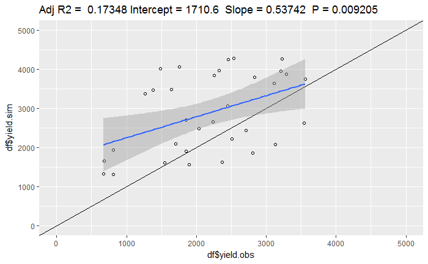

```r
ggplotRegression("Input\\observed_spring_canola_peas_wheat_planting_dates.txt", "Input\\17-05-09_15_season_all.dat")
```

- Nope, SLA had an effect. So CropSyst isn’t responding to changes in stressors. WHAT?!!!

## SC16: specific_leaf_area 28 -> 30; duration_stress_sensitivity 0.1 -> 1

https://github.com/bryanrcarlson/LtarModelingFlexCropping_CropSyst/commit/39e6ff1373c7d352cfe7b77b439acdc8185f5bf1#diff-8fb462d4d9caaeef85ac8a8f5a530157

```r
ggplotRegression("Input\\observed_spring_canola_peas_wheat_planting_dates.txt", "Input\\17-05-09_16_season_all.dat")
```

```
Call:
lm(formula = yield.sim ~ yield.obs, data = df)

Residuals:
     Min       1Q   Median       3Q      Max
-1762.55  -646.71    75.05   650.37  1691.15

Coefficients:
             Estimate Std. Error t value Pr(>|t|)
(Intercept) 1676.6646   457.9619   3.661 0.000928 ***
yield.obs      0.7452     0.1966   3.790 0.000652 ***
---
Signif. codes:  0 *** 0.001 ** 0.01 * 0.05 . 0.1   1

Residual standard error: 925.2 on 31 degrees of freedom
Multiple R-squared:  0.3167,    Adjusted R-squared:  0.2946
F-statistic: 14.37 on 1 and 31 DF,  p-value: 0.0006521
```

## SC17: heat_stress_exposure_initial_hour 99 -> 1

https://github.com/bryanrcarlson/LtarModelingFlexCropping_CropSyst/commit/24408f5f85209eb1e8e9a253a3a01fc200166c34#diff-8fb462d4d9caaeef85ac8a8f5a530157 * Testing whether “arbitrary” (setting above value to 99) breaks grain stress. … NOPE!

```r
ggplotRegression("Input\\observed_spring_canola_peas_wheat_planting_dates.txt", "Input\\17-05-09_17_season_all.dat")
```

```
Call:
lm(formula = yield.sim ~ yield.obs, data = df)

Residuals:
     Min       1Q   Median       3Q      Max
-1762.55  -646.71    75.05   650.37  1691.15

Coefficients:
             Estimate Std. Error t value Pr(>|t|)
(Intercept) 1676.6646   457.9619   3.661 0.000928 ***
yield.obs      0.7452     0.1966   3.790 0.000652 ***
---
Signif. codes:  0 *** 0.001 ** 0.01 * 0.05 . 0.1   1

Residual standard error: 925.2 on 31 degrees of freedom
Multiple R-squared:  0.3167,    Adjusted R-squared:  0.2946
F-statistic: 14.37 on 1 and 31 DF,  p-value: 0.0006521
```

## SC18: Does grain_stress_period do anything? checked, enabled from true->false; grain_stress_period:count 1->0

https://github.com/bryanrcarlson/LtarModelingFlexCropping_CropSyst/commit/24408f5f85209eb1e8e9a253a3a01fc200166c34#diff-8fb462d4d9caaeef85ac8a8f5a530157

```
Call:
lm(formula = yield.sim ~ yield.obs, data = df)

Residuals:
     Min       1Q   Median       3Q      Max
-1780.53  -670.49    55.76   629.55  1670.03

Coefficients:
             Estimate Std. Error t value Pr(>|t|)
(Intercept) 1702.7063   461.5727   3.689  0.00086 ***
yield.obs      0.7419     0.1982   3.744  0.00074 ***
---
Signif. codes:  0 *** 0.001 ** 0.01 * 0.05 . 0.1   1

Residual standard error: 932.5 on 31 degrees of freedom
Multiple R-squared:  0.3114,    Adjusted R-squared:  0.2891
F-statistic: 14.02 on 1 and 31 DF,  p-value: 0.0007404
```

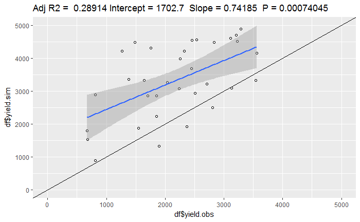

```r
ggplotRegression("Input\\observed_spring_canola_peas_wheat_planting_dates.txt", "Input\\17-05-09_18_season_all.dat")
```

- So the effect is very small, but it is functioning. It looks like having it implemented pulled a few points down towards the 1:1 line – good! Now, how to make that more significant?

## SC19: Increase time of flowering to make grain_stress_period more impactful. filling: 790->1090. Also enabled grain stress.

https://github.com/bryanrcarlson/LtarModelingFlexCropping_CropSyst/commit/8a23ec9132227c0f8ff78e065f03419c47f6ed71#diff-8fb462d4d9caaeef85ac8a8f5a530157

```
Call:
lm(formula = yield.sim ~ yield.obs, data = df)

Residuals:
    Min      1Q  Median      3Q     Max
-897.28 -240.12  -14.93  239.06  860.55

Coefficients:
             Estimate Std. Error t value Pr(>|t|)
(Intercept) 613.48975  203.10764   3.021 0.005020 **
yield.obs     0.34970    0.08719   4.011 0.000355 ***
---
Signif. codes:  0 *** 0.001 ** 0.01 * 0.05 . 0.1   1

Residual standard error: 410.3 on 31 degrees of freedom
Multiple R-squared:  0.3416,    Adjusted R-squared:  0.3204
F-statistic: 16.09 on 1 and 31 DF,  p-value: 0.0003547
```

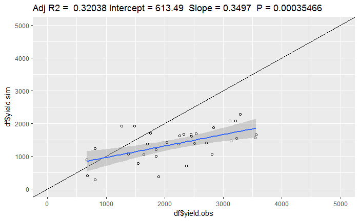

```r
ggplotRegression("Input\\observed_spring_canola_peas_wheat_planting_dates.txt", "Input\\17-05-09_19_season_all.dat")
```

## SC20: filling: 1090 -> 990

https://github.com/bryanrcarlson/LtarModelingFlexCropping_CropSyst/commit/aab974900be9698c0c19b75b26e6632c0cb12bd1#diff-8fb462d4d9caaeef85ac8a8f5a530157

```
Call:
lm(formula = yield.sim ~ yield.obs, data = df)

Residuals:
    Min      1Q  Median      3Q     Max
-1247.8  -348.7   -51.5   444.5  1176.2

Coefficients:
            Estimate Std. Error t value Pr(>|t|)
(Intercept) 807.5986   290.6548   2.779 0.009190 **
yield.obs     0.5123     0.1248   4.105 0.000272 ***
---
Signif. codes:  0 *** 0.001 ** 0.01 * 0.05 . 0.1   1

Residual standard error: 587.2 on 31 degrees of freedom
Multiple R-squared:  0.3522,    Adjusted R-squared:  0.3313
F-statistic: 16.85 on 1 and 31 DF,  p-value: 0.0002723
```

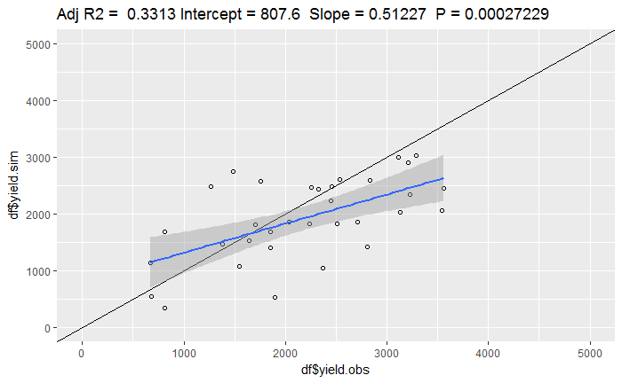

```r
ggplotRegression("Input\\observed_spring_canola_peas_wheat_planting_dates.txt", "Input\\17-05-09_20_season_all.dat")
```

## SC21: specific_leaf_area: 30->33

https://github.com/bryanrcarlson/LtarModelingFlexCropping_CropSyst/commit/752eeaece4f88143c38074081875a2eb0c0f3f13#diff-8fb462d4d9caaeef85ac8a8f5a530157

```
Call:
lm(formula = yield.sim ~ yield.obs, data = df)

Residuals:
    Min      1Q  Median      3Q     Max
-1591.1  -380.6   163.3   512.7  1146.5

Coefficients:
            Estimate Std. Error t value Pr(>|t|)
(Intercept) 932.7851   332.4707   2.806 0.008598 **
yield.obs     0.5584     0.1427   3.912 0.000466 ***
---
Signif. codes:  0 *** 0.001 ** 0.01 * 0.05 . 0.1   1

Residual standard error: 671.7 on 31 degrees of freedom
Multiple R-squared:  0.3305,    Adjusted R-squared:  0.309
F-statistic: 15.31 on 1 and 31 DF,  p-value: 0.0004658
```

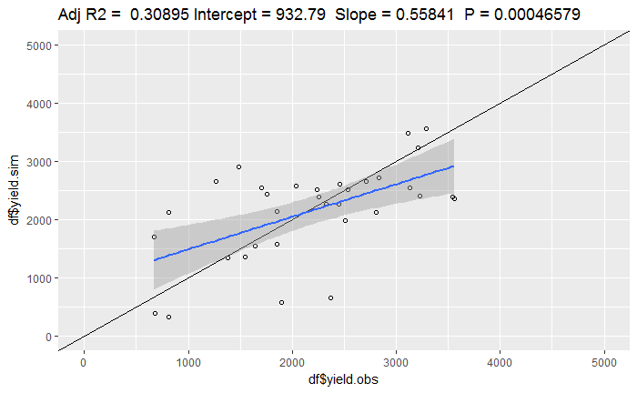

```r
ggplotRegression("Input\\observed_spring_canola_peas_wheat_planting_dates.txt", "Input\\17-05-09_21_season_all.dat")
```